# ExtraaLearn Startup Project

## A Classification Project (Supervised Learning)

## by Elvis Ibor, MIT Certified Data Scientist.

### **(To verify this certificate visit verify.mygreatlearning.com/MKKOWHSQ)**

## Context:

The EdTech industry has been surging in the past decade immensely, and according to a forecast, the Online Education market would be worth $286.62bn by 2023 with a compound annual growth rate (CAGR) of 10.26% from 2018 to 2023. The modern era of online education has enforced a lot in its growth and expansion beyond any limit. Due to having many dominant features like ease of information sharing, personalized learning experience, transparency of assessment, etc, it is now preferable to traditional education.

In the present scenario due to the Covid-19, the online education sector has witnessed rapid growth and is attracting a lot of new customers. Due to this rapid growth, many new companies have emerged in this industry. With the availability and ease of use of digital marketing resources, companies can reach out to a wider audience with their offerings. The customers who show interest in these offerings are termed as leads. There are various sources of obtaining leads for Edtech companies, like

- The customer interacts with the marketing front on social media or other online platforms.
- The customer browses the website/app and downloads the brochure
- The customer connects through emails for more information.

The company then nurtures these leads and tries to convert them to paid customers. For this, the representative from the organization connects with the lead on call or through email to share further details.

## Objective

ExtraaLearn is an initial stage startup that offers programs on cutting-edge technologies to students and professionals to help them upskill/reskill. With a large number of leads being generated on a regular basis, one of the issues faced by ExtraaLearn is to identify which of the leads are more likely to convert so that they can allocate resources accordingly. You, as a data scientist at ExtraaLearn, have been provided the leads data to:

- Analyze and build an ML model to help identify which leads are more likely to convert to paid customers,
- Find the factors driving the lead conversion process
- Create a profile of the leads which are likely to convert

## Appraoch to Solution:

## Data Description

The data contains the different attributes of leads and their interaction details with ExtraaLearn. The detailed data dictionary is given below.

**Data Dictionary**

- ID: ID of the lead
- age: Age of the lead
- current_occupation: Current occupation of the lead. Values include 'Professional','Unemployed',and 'Student'
- first_interaction: How did the lead first interacted with ExtraaLearn. Values include 'Website', 'Mobile App'
- profile_completed: What percentage of profile has been filled by the lead on the website/mobile app. Values include Low - (0-50%), Medium - (50-75%), High (75-100%)
- website_visits: How many times has a lead visited the website
- time_spent_on_website: Total time spent on the website
- page_views_per_visit: Average number of pages on the website viewed during the visits.
- last_activity: Last interaction between the lead and ExtraaLearn.
  - Email Activity: Seeking for details about program through email, Representative shared information with lead like brochure of program , etc
  - Phone Activity: Had a Phone Conversation with representative, Had conversation over SMS with representative, etc
  - Website Activity: Interacted on live chat with representative, Updated profile on website, etc
- print_media_type1: Flag indicating whether the lead had seen the ad of ExtraaLearn in the Newspaper.
- print_media_type2: Flag indicating whether the lead had seen the ad of ExtraaLearn in the Magazine.
- digital_media: Flag indicating whether the lead had seen the ad of ExtraaLearn on the digital platforms.
- educational_channels: Flag indicating whether the lead had heard about ExtraaLearn in the education channels like online forums, discussion threads, educational websites, etc.
- referral: Flag indicating whether the lead had heard about ExtraaLearn through reference.
- status: Flag indicating whether the lead was converted to a paid customer or not.

## Importing necessary libraries and data

```python
# Suppress warnings
import warnings
from statsmodels.tools.sm_exceptions import ConvergenceWarning
warnings.filterwarnings("ignore")
warnings.simplefilter("ignore", ConvergenceWarning)

# Importing libraries for reading and manipulation of data
import numpy as np
import pandas as pd

# Libraries for data visualization
import matplotlib.pyplot as plt
import seaborn as sns

# Libraries to split data
from sklearn.model_selection import train_test_split

# Libraries to build models for prediction
import statsmodels.stats.api as sms
from statsmodels.stats.outliers_influence import variance_inflation_factor
import statsmodels.api as sms  # Using sms as an alias for statsmodels
from statsmodels.tools.tools import add_constant
from sklearn.linear_model import LogisticRegression
from sklearn.tree import DecisionTreeClassifier
from sklearn import tree
from sklearn.ensemble import RandomForestClassifier

# To remove limits from the number of displayed columns
pd.options.display.max_columns = None
# To set the limits for the number of displayed rows to 200
pd.options.display.max_rows = 200
# To set the precision of floats to 4 decimal points
pd.options.display.float_format = lambda x: "%.4f" % x

# Libraries to tune different models.
from sklearn.model_selection import GridSearchCV

# Libraries with attributes for different metric scores
import sklearn.metrics as metrics
from sklearn.metrics import (
    f1_score, accuracy_score, precision_score, confusion_matrix,
    classification_report, roc_auc_score, precision_recall_curve,
    roc_curve, make_scorer)
```

## Data Overview

- Observations
- Sanity checks

### Loading the Dataset

```python
# lets load or import our dataset as leads_data
leads_data = pd.read_csv("ExtraaLearn.csv")
```

### Creating a Copy of the Dataset

```python
data = leads_data.copy()
```

### Viewing the Dataset

```python
# viewing the dataset:first 5 rows
leads_data.head()
```

|  | ID | age | current_occupation | first_interaction | profile_completed | website_visits | time_spent_on_website | page_views_per_visit | last_activity | print_media_type1 | print_media_type2 | digital_media | educational_channels | referral | status |
| --- | --- | --- | --- | --- | --- | --- | --- | --- | --- | --- | --- | --- | --- | --- | --- |
| 0 | EXT001 | 57 | Unemployed | Website | High | 7 | 1639 | 1.8610 | Website Activity | Yes | No | Yes | No | No | 1 |
| 1 | EXT002 | 56 | Professional | Mobile App | Medium | 2 | 83 | 0.3200 | Website Activity | No | No | No | Yes | No | 0 |
| 2 | EXT003 | 52 | Professional | Website | Medium | 3 | 330 | 0.0740 | Website Activity | No | No | Yes | No | No | 0 |
| 3 | EXT004 | 53 | Unemployed | Website | High | 4 | 464 | 2.0570 | Website Activity | No | No | No | No | No | 1 |
| 4 | EXT005 | 23 | Student | Website | High | 4 | 600 | 16.9140 | Email Activity | No | No | No | No | No | 0 |

```python
#viewing the dataset: last 5 rows
leads_data.tail()
```

|  | ID | age | current_occupation | first_interaction | profile_completed | website_visits | time_spent_on_website | page_views_per_visit | last_activity | print_media_type1 | print_media_type2 | digital_media | educational_channels | referral | status |
| --- | --- | --- | --- | --- | --- | --- | --- | --- | --- | --- | --- | --- | --- | --- | --- |
| 4607 | EXT4608 | 35 | Unemployed | Mobile App | Medium | 15 | 360 | 2.1700 | Phone Activity | No | No | No | Yes | No | 0 |
| 4608 | EXT4609 | 55 | Professional | Mobile App | Medium | 8 | 2327 | 5.3930 | Email Activity | No | No | No | No | No | 0 |
| 4609 | EXT4610 | 58 | Professional | Website | High | 2 | 212 | 2.6920 | Email Activity | No | No | No | No | No | 1 |
| 4610 | EXT4611 | 57 | Professional | Mobile App | Medium | 1 | 154 | 3.8790 | Website Activity | Yes | No | No | No | No | 0 |
| 4611 | EXT4612 | 55 | Professional | Website | Medium | 4 | 2290 | 2.0750 | Phone Activity | No | No | No | No | No | 0 |

### Viewing the Shape of the Dataset

```python
leads_data.shape
```

```
(4612, 15)
```

### Observation

- The dataset has 4,612 rows and 15 columns

## Viewing the datatypes of the columns for the dataset

```python
leads_data.info()
```

```
<class 'pandas.core.frame.DataFrame'>
RangeIndex: 4612 entries, 0 to 4611
Data columns (total 15 columns):
 #   Column                 Non-Null Count  Dtype
---  ------                 --------------  -----
 0   ID                     4612 non-null   object
 1   age                    4612 non-null   int64
 2   current_occupation     4612 non-null   object
 3   first_interaction      4612 non-null   object
 4   profile_completed      4612 non-null   object
 5   website_visits         4612 non-null   int64
 6   time_spent_on_website  4612 non-null   int64
 7   page_views_per_visit   4612 non-null   float64
 8   last_activity          4612 non-null   object
 9   print_media_type1      4612 non-null   object
 10  print_media_type2      4612 non-null   object
 11  digital_media          4612 non-null   object
 12  educational_channels   4612 non-null   object
 13  referral               4612 non-null   object
 14  status                 4612 non-null   int64
dtypes: float64(1), int64(4), object(10)
memory usage: 540.6+ KB
```

### Observation

1. There are 10 object data types
2. There are 5 numerical data types : 1 float and 4 integers data types respectively.
3. There are a total of 15 columns of nun null values in the dataset indicating no missing values.

### Checking for Duplicates

```python
# checking for duplicates using the duplicated() and  boolean (if/else) function
duplicate_count = leads_data.duplicated().sum()

if duplicate_count == 0:
    print("No duplicates found in the dataset.")
else:
    print(f"{duplicate_count} duplicates found in the dataset.")
```

```
No duplicates found in the dataset.
```

## Exploratory Data Analysis (EDA)

- EDA is an important part of any project involving data.
- It is important to investigate and understand the data better before building a model with it.
- A few questions have been mentioned below which will help us approach the analysis in the right manner and generate insights from the data.
- A thorough analysis of the data, in addition to the questions mentioned below, would be done.

**Questions**

1. Leads will have different expectations from the outcome of the course and the current occupation may play a key role in getting them to participate in the program. Find out how current occupation affects lead status.
2. The company's first impression on the customer must have an impact. Do the first channels of interaction have an impact on the lead status?
3. The company uses multiple modes to interact with prospects. Which way of interaction works best?
4. The company gets leads from various channels such as print media, digital media, referrals, etc. Which of these channels have the highest lead conversion rate?
5. People browsing the website or mobile application are generally required to create a profile by sharing their personal data before they can access additional information.Does having more details about a prospect increase the chances of conversion?

## Understanding the Summary Statistics of the Dataset

```python
# checking the summary statistics of the numerical variables
leads_data.describe()
```

|  | age | website_visits | time_spent_on_website | page_views_per_visit | status |
| --- | --- | --- | --- | --- | --- |
| count | 4612.0000 | 4612.0000 | 4612.0000 | 4612.0000 | 4612.0000 |
| mean | 46.2012 | 3.5668 | 724.0113 | 3.0261 | 0.2986 |
| std | 13.1615 | 2.8291 | 743.8287 | 1.9681 | 0.4577 |
| min | 18.0000 | 0.0000 | 0.0000 | 0.0000 | 0.0000 |
| 25% | 36.0000 | 2.0000 | 148.7500 | 2.0777 | 0.0000 |
| 50% | 51.0000 | 3.0000 | 376.0000 | 2.7920 | 0.0000 |
| 75% | 57.0000 | 5.0000 | 1336.7500 | 3.7562 | 1.0000 |
| max | 63.0000 | 30.0000 | 2537.0000 | 18.4340 | 1.0000 |

```python
leads_data.describe().T
```

|  | count | mean | std | min | 25% | 50% | 75% | max |
| --- | --- | --- | --- | --- | --- | --- | --- | --- |
| age | 4612.0000 | 46.2012 | 13.1615 | 18.0000 | 36.0000 | 51.0000 | 57.0000 | 63.0000 |
| website_visits | 4612.0000 | 3.5668 | 2.8291 | 0.0000 | 2.0000 | 3.0000 | 5.0000 | 30.0000 |
| time_spent_on_website | 4612.0000 | 724.0113 | 743.8287 | 0.0000 | 148.7500 | 376.0000 | 1336.7500 | 2537.0000 |
| page_views_per_visit | 4612.0000 | 3.0261 | 1.9681 | 0.0000 | 2.0777 | 2.7920 | 3.7562 | 18.4340 |
| status | 4612.0000 | 0.2986 | 0.4577 | 0.0000 | 0.0000 | 0.0000 | 1.0000 | 1.0000 |

## Observation

**Age Distribution:** The age of leads ranges from 18 to 63 years. The mean age is approximately 46 years, with a standard deviation of around 13.16 years. The majority of leads fall between the age of 36 and 57, as indicated by the interquartile range (IQR) between the 25th and 75th percentiles.

**Website Interaction:** The average number of website visits is around 3.57, with a maximum of 30 visits. The mean time spent on the website is 724.01, with a wide standard deviation of 743.83. The average number of page views per visit is 3.03, with a maximum of 18.43.

**Lead Status:** The target variable "status" has a mean value of approximately 0.30, suggesting that around 30% of leads have converted to paid customers. The minimum and maximum values for "status" indicate a binary outcome (0 or 1), where 0 represents leads that did not convert, and 1 represents leads that converted.

### Creating a List of Categorical Variables

```python
# creating a list of all catrgorical variables
cat_var = list(data.select_dtypes("object").columns)

# Printing number of count of each unique value of the categorical variables
for column in cat_var:
    print(data[column].value_counts())
    print("-" * 40)
```

```
EXT001     1
EXT2884    1
EXT3080    1
EXT3079    1
EXT3078    1
          ..
EXT1537    1
EXT1536    1
EXT1535    1
EXT1534    1
EXT4612    1
Name: ID, Length: 4612, dtype: int64
----------------------------------------
Professional    2616
Unemployed      1441
Student          555
Name: current_occupation, dtype: int64
----------------------------------------
Website       2542
Mobile App    2070
Name: first_interaction, dtype: int64
----------------------------------------
High      2264
Medium    2241
Low        107
Name: profile_completed, dtype: int64
----------------------------------------
Email Activity      2278
Phone Activity      1234
Website Activity    1100
Name: last_activity, dtype: int64
----------------------------------------
No     4115
Yes     497
Name: print_media_type1, dtype: int64
----------------------------------------
No     4379
Yes     233
Name: print_media_type2, dtype: int64
----------------------------------------
No     4085
Yes     527
Name: digital_media, dtype: int64
----------------------------------------
No     3907
Yes     705
Name: educational_channels, dtype: int64
----------------------------------------
No     4519
Yes      93
Name: referral, dtype: int64
----------------------------------------
```

## Check for unique value count

```python
#checking the value counts of the data
unique_value_counts = leads_data.nunique()
print(unique_value_counts)
```

```
ID                       4612
age                        46
current_occupation          3
first_interaction           2
profile_completed           3
website_visits             27
time_spent_on_website    1623
page_views_per_visit     2414
last_activity               3
print_media_type1           2
print_media_type2           2
digital_media               2
educational_channels        2
referral                    2
status                      2
dtype: int64
```

```python
# Checking unique values for ID column
id_unique_count = leads_data['ID'].nunique()
print(f"Number of unique values in 'ID': {id_unique_count}")
```

```
Number of unique values in 'ID': 4612
```

### To Drop the ID column from the dataset

```python
# peremanently droping the ID column in the dataset
leads_data.drop(columns=['ID'], axis = 1, inplace = True)
```

```python
# lets the modified dataset leads_data without ID column
leads_data.head()
```

[output not shown]

## Univariate Analysis of the Dataset

```python
# lets create a boxplot and histogram function

def plot_box_hist(data, car_var):
    # Set up the figure and axes
    fig, (ax_box, ax_hist) = plt.subplots(2, gridspec_kw={"height_ratios": (.15, .85)}, figsize=(8, 6))

    # Boxplot
    sns.boxplot(data=data, x=car_var, ax=ax_box)

    # Histogram
    sns.histplot(data[car_var], kde=False, bins=20, ax=ax_hist)

    # Add labels and title
    ax_box.set(xlabel='')  # Remove x-axis label from boxplot
    ax_hist.set(xlabel=car_var, ylabel='Frequency')

    # Adjust layout
    plt.tight_layout()
```

### Univariate Analysis for Age

```python
# Lets keep the summary statistics handy as a referrence for our analysis
leads_data.describe().T
```

|  | count | mean | std | min | 25% | 50% | 75% | max |
| --- | --- | --- | --- | --- | --- | --- | --- | --- |
| age | 4612.0000 | 46.2012 | 13.1615 | 18.0000 | 36.0000 | 51.0000 | 57.0000 | 63.0000 |
| website_visits | 4612.0000 | 3.5668 | 2.8291 | 0.0000 | 2.0000 | 3.0000 | 5.0000 | 30.0000 |
| time_spent_on_website | 4612.0000 | 724.0113 | 743.8287 | 0.0000 | 148.7500 | 376.0000 | 1336.7500 | 2537.0000 |
| page_views_per_visit | 4612.0000 | 3.0261 | 1.9681 | 0.0000 | 2.0777 | 2.7920 | 3.7562 | 18.4340 |
| status | 4612.0000 | 0.2986 | 0.4577 | 0.0000 | 0.0000 | 0.0000 | 1.0000 | 1.0000 |

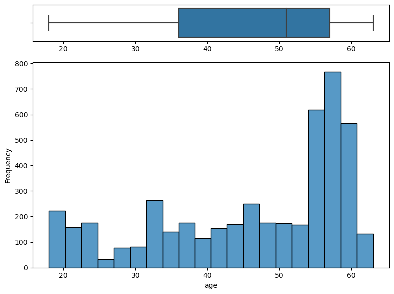

```python
plot_box_hist(leads_data, 'age')
plt.show()
```

### Observatiion on Age.

1.The boxplot for age shows the distribution for the age of the leads is left skewed with a long whisker but no presence of outliers. This shows that the left-skewed distribution with a long left whisker in the age boxplot indicates that the majority of leads are older, with a gradual decrease in frequency towards younger ages. The absence of outliers suggests that the age values are relatively consistent without any extreme values.

## Univariate Analysis on website_visits

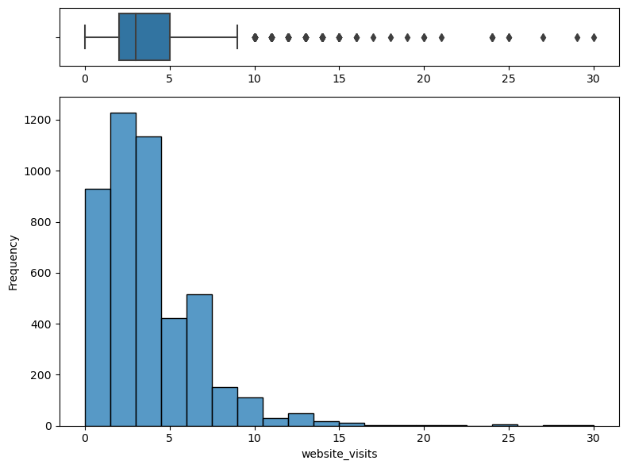

```python
plot_box_hist(leads_data, 'website_visits')
plt.show()
```

### Obervation On website Visits.

1.The boxplot shows right-skewed distribution of website visits with a longer right whisker, numerous outliers, a median around 3, and an interquartile range between 2 and 5 indicating that while the majority of leads have relatively lower website visits, there is a subset of leads with exceptionally high website visit values, contributing to the skewness and the presence of outliers.

2.The website visits histogram suggests a bimodal distribution with a peak concentration of leads with lower website visits and a spread to the right, indicating the presence of a subset of leads who are more actively engaging with the website. This diversity in engagement levels among leads could have implications for marketing strategies and targeted outreach efforts. such as 1.Targeted engagement strategies, 2.Iddentifying active leads,and 3.OPtimizing website experience.

```python
# Create a binary column indicating whether a lead has visited the website or not.
leads_data['visited_website'] = (leads_data['website_visits'] > 0).astype(int)

# Count the number of leads who have not visited the website and those who have.
not_visited_count = leads_data['visited_website'].value_counts().get(0, 0)
visited_count = leads_data['visited_website'].value_counts().get(1, 0)

# Print the counts.
print(f"Number of leads who have not visited the website: {not_visited_count}")
print(f"Number of leads who have visited the website: {visited_count}")
```

```
Number of leads who have not visited the website: 174
Number of leads who have visited the website: 4438
```

## Univariate Analysis for time_spent_on_website.

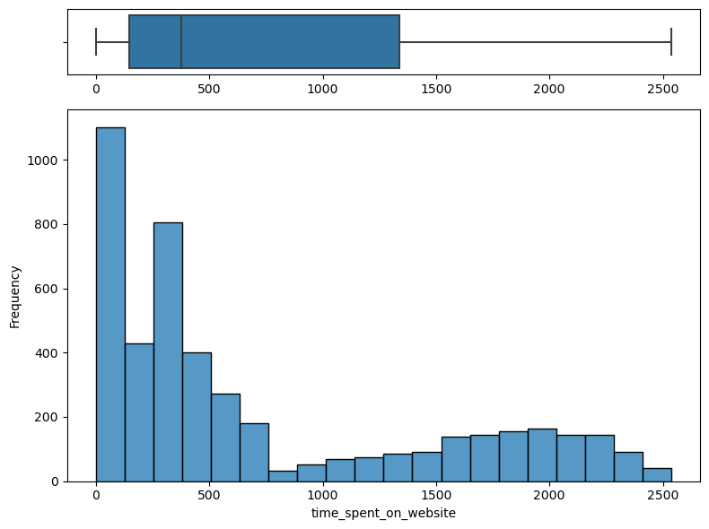

```python
plot_box_hist(leads_data, "time_spent_on_website")
plt.show()
```

### Observation od time spent on website

1.The majority of leads (within the IQR) spend varying amounts of time on the website, ranging from approximately 150 to 1300. There is a subset of leads (beyond the IQR, towards the right) who spend significantly more time on the website. The median at 380 provides a central reference point, showing that the distribution is not symmetric, with more leads spending less time compared to those spending more.

## Univariate Analysis on page view per visit

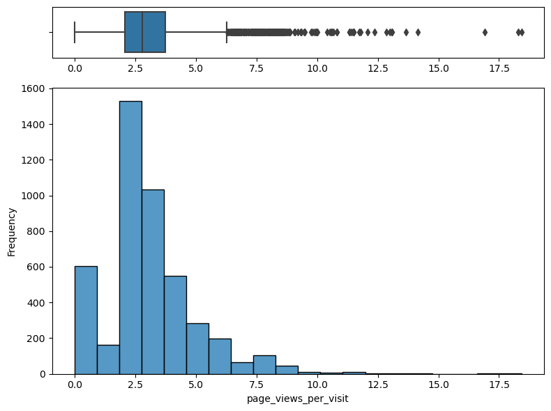

```python
plot_box_hist(leads_data, "page_views_per_visit")
plt.show()
```

### Observation on page views per visits

1.The overall distribution appears to be centered around the median value of 3, with a concentration of leads having page views per visit around 2.5.

2.The presence of outliers on the right side of the distribution suggests that there is a subset of leads who exhibit higher-than-average engagement, resulting in an extended right tail in both the boxplot and histplot.

```python
# creating a function for barplots
def labeled_barplot(data, feature, xlabel, ylabel, title):
    """
    Create a labeled barplot for a specific feature.

    Parameters:
    - data: DataFrame, the dataset
    - feature: str, the feature for which the barplot is created
    - xlabel: str, label for the x-axis
    - ylabel: str, label for the y-axis
    - title: str, title for the plot
    """
    plt.figure(figsize=(10, 6))
    sns.countplot(x=feature, data=data, palette="viridis")

    plt.title(title, fontsize=16)
    plt.xlabel(xlabel, fontsize=14)
    plt.ylabel(ylabel, fontsize=14)

    # Display count labels on top of the bars
    for p in plt.gca().patches:
        plt.gca().annotate(f'{p.get_height()}', (p.get_x() + p.get_width() / 2., p.get_height()),
                           ha='center', va='center', xytext=(0, 10), textcoords='offset points')

    plt.show()
```

## Analysis of Current Current Occupation

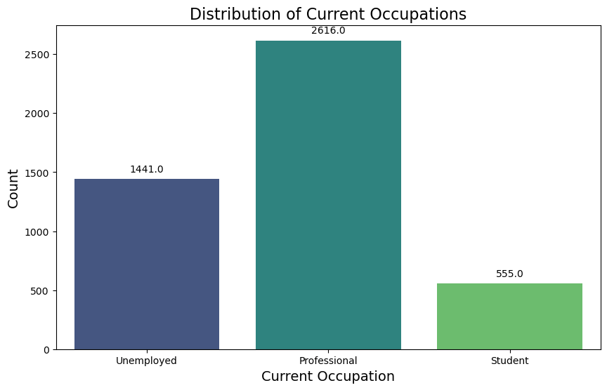

```python
# for the 'current_occupation' feature
labeled_barplot(leads_data, 'current_occupation', 'Current Occupation', 'Count', 'Distribution of Current Occupations')
```

### Observation

The distribution of current occupations among leads reflects a diverse audience, with a strong presence of professionals, a notable representation of unemployed individuals, and engagement from students.

## Analysis for first interaction

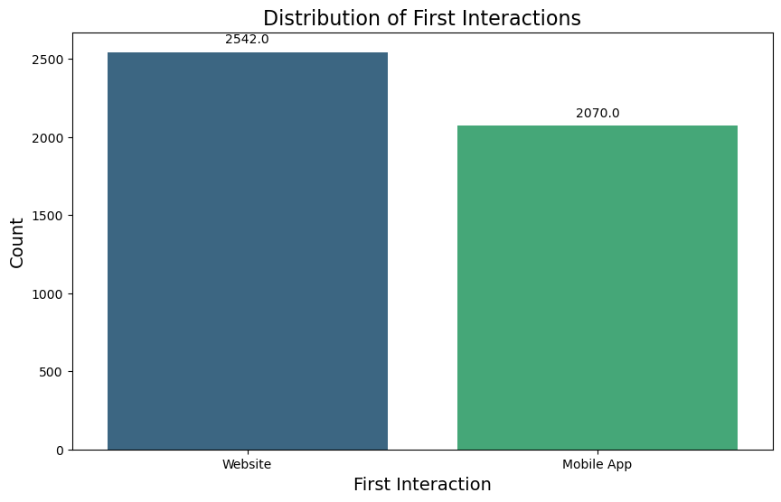

```python
labeled_barplot(leads_data, 'first_interaction', 'First Interaction', 'Count', 'Distribution of First Interactions')
plt.show()
```

### Observation

The difference in counts between the 'Website' and 'Mobile App' categories in the 'first_interaction' feature indicates the variation in lead preferences for the initial interaction platform. Leads tend to have more prefernce for website than mobile applications

## Analysis for Profile Completed

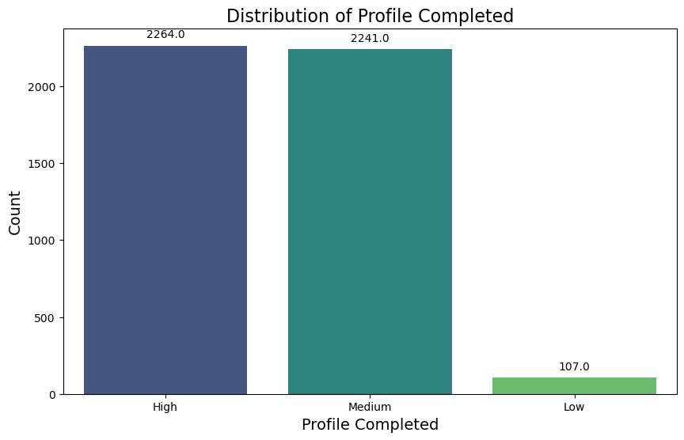

```python
labeled_barplot(leads_data, "profile_completed", 'Profile Completed', 'Count', 'Distribution of Profile Completed')
plt.show()
```

### Observation

The higher counts in the 'High' and 'Medium' categories suggest a positive trend, indicating that a substantial number of leads are actively engaging and completing their profiles. Targeted strategies can be implemented to encourage leads in the 'Low' category to complete more of their profiles, fostering deeper engagement.

## Last Activity Analysis

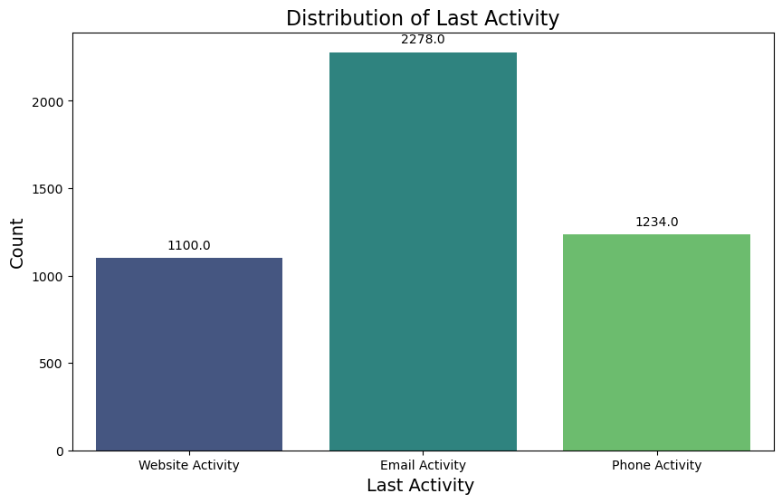

```python
labeled_barplot(leads_data, 'last_activity', 'Last Activity ', 'Count', 'Distribution of Last Activity')
plt.show()
```

### Observation

The diversity in last activity channels indicates a multi-channel approach by ExtraaLearn to engage with leads. A high count in 'Email Activity' suggests the importance of email communication, emphasizing the need for effective email marketing strategies and personalized communication.

## Analysis on Print Media Type 1

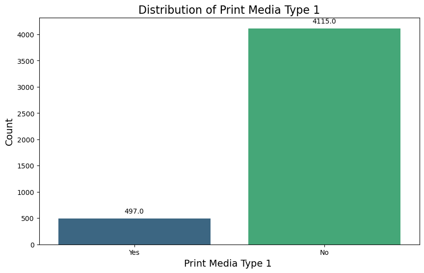

```python
labeled_barplot(leads_data, 'print_media_type1', 'Print Media Type 1 ', 'Count', 'Distribution of Print Media Type 1')
plt.show()
```

### Observation

The count of 497 indicates that a subset of leads has been exposed to ExtraaLearn's advertisements in Print Media Type 1.

The higher count of 4115 suggests that the majority of leads have not encountered ExtraaLearn's ad in Print Media Type 1.

## Analysis of Print Media Type 2

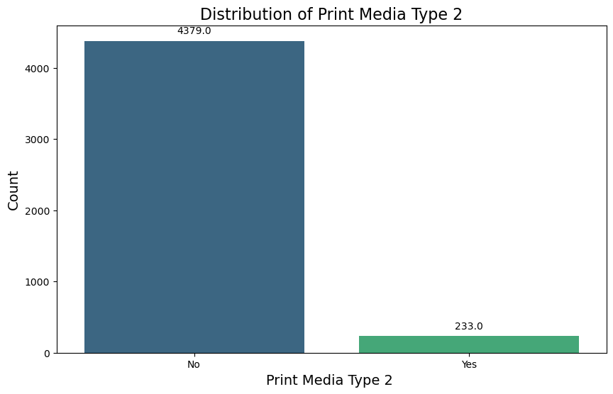

```python
labeled_barplot(leads_data, 'print_media_type2', 'Print Media Type 2 ', 'Count', 'Distribution of Print Media Type 2')
plt.show()
```

### Observation

Yes (Print Media Type 2): The count of 233 indicates that a subset of leads has been exposed to ExtraaLearn's advertisements in Print Media Type 2. Leads in this category may have come across ExtraaLearn's ad in magazines or other specified print media, suggesting awareness through these advertising channels.

No (Print Media Type 2): The higher count of 4379 suggests that the majority of leads have not encountered ExtraaLearn's ad in Print Media Type 2. This could imply that a significant portion of leads might not have been reached or influenced by the specific print media advertising in question.

## Analysis of Digital Media

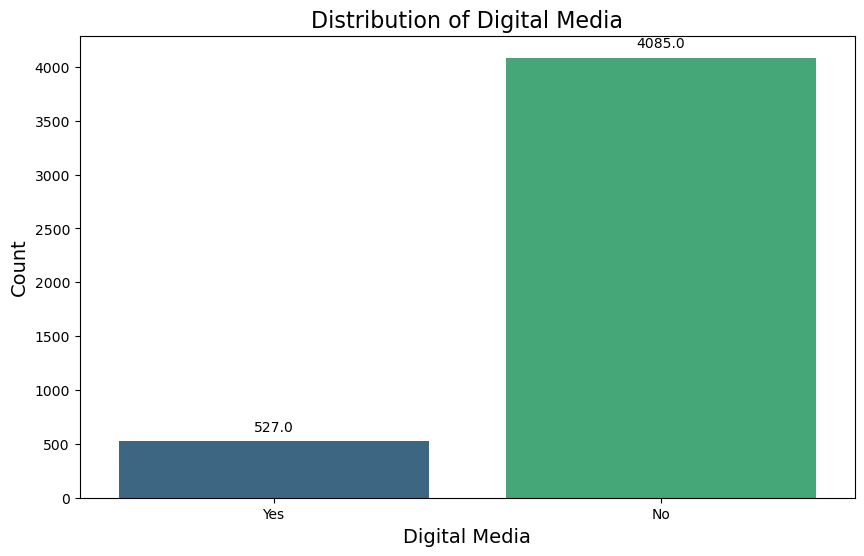

```python
labeled_barplot(leads_data, 'digital_media', 'Digital Media', 'Count', 'Distribution of Digital Media')
plt.show()
```

### Observation

Yes (Digital Media): The count of 527 indicates that a subset of leads has been exposed to ExtraaLearn's advertisements on digital platforms. Leads in this category may have encountered ExtraaLearn's ad on online platforms, websites, social media, or other digital channels.

No (Digital Media): The higher count of 4085 suggests that the majority of leads have not encountered ExtraaLearn's ad on digital platforms. This could imply that a significant portion of leads might not have been reached or influenced by digital media advertising.

## Analysis of Educational Channels

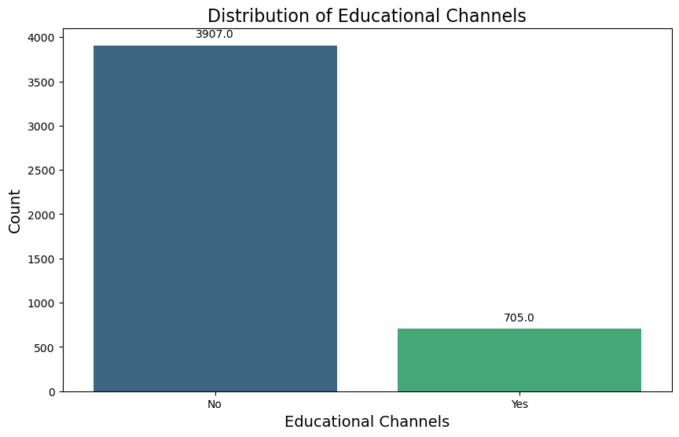

```python
labeled_barplot(leads_data, 'educational_channels', 'Educational Channels', 'Count', 'Distribution of Educational Channels')
plt.show()
```

### Observation

Yes (Educational Channels): The count of 705 indicates that a subset of leads has learned about ExtraaLearn through educational channels. Leads in this category may have discovered ExtraaLearn through online forums, discussions, educational websites, or other educational platforms.

No (Educational Channels): The higher count of 3907 suggests that the majority of leads have not learned about ExtraaLearn through educational channels. This could imply that a significant portion of leads might have been introduced to ExtraaLearn through other non-educational means.

## Analysis of Referral

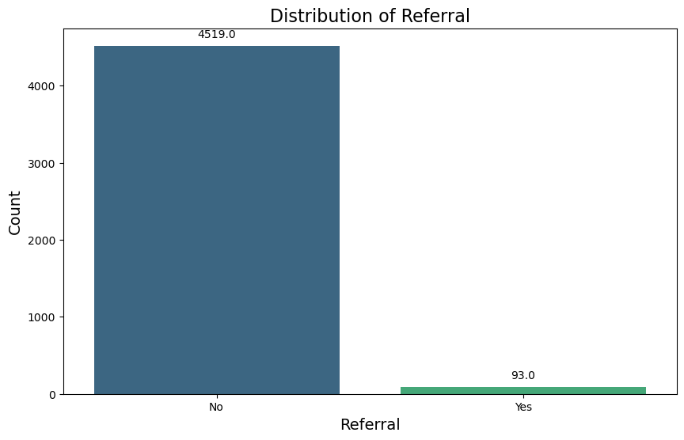

```python
labeled_barplot(leads_data, 'referral', 'Referral', 'Count', 'Distribution of Referral')
plt.show()
```

### Observation

Yes (Referral): The count of 93 indicates that a small subset of leads has learned about ExtraaLearn through referrals from others. Leads in this category may have been referred to ExtraaLearn by friends, colleagues, or acquaintances.

No (Referral): The higher count of 4519 suggests that the majority of leads have not learned about ExtraaLearn through referrals. This could imply that a significant portion of leads may have discovered ExtraaLearn through other channels such as digital marketing, educational platforms, or direct interaction.

## Analysis for Status

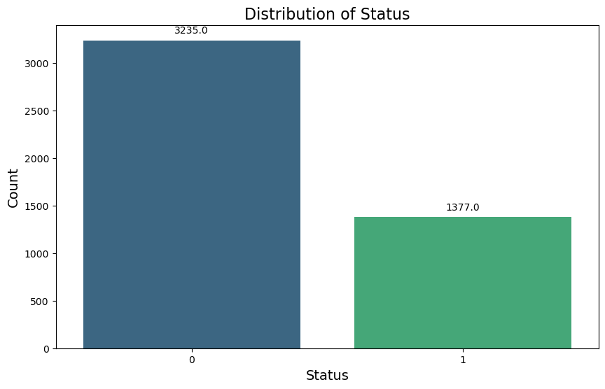

```python
labeled_barplot(leads_data, 'status', 'Status', 'Count', 'Distribution of Status')
plt.show()
```

### Observation

The counts in the '0' and '1' categories for 'status' indicate the distribution of leads based on whether they have converted to paid customers or not.

0 (Not Converted to Paid Customer): The count of 3235 indicates the number of leads that have not converted to paid customers. Leads in this category have not progressed to the stage of becoming paying customers of ExtraaLearn.

1 (Converted to Paid Customer) The count of 1377 indicates the number of leads that have successfully converted to paid customers. Leads in this category have completed the conversion process and become paying customers of ExtraaLearn.

### Observations from the Univariate Analysis - Summary

The Observations from the univariate analysis can be summarized as follows:

Page Views Per Visit: The boxplot shows near-equal whiskers with outliers on the right after the 6.0 point. The histogram peaks at 2.5 and is right-skewed to about 17.5.

Status (Conversion): The majority of leads (3235) have not converted to paid customers (Status 0). A substantial portion (1377) has successfully converted to paid customers (Status 1).

Print Media Type 1: A total of 497 leads have seen the ad in Print Media Type 1, while 4115 have not.

Print Media Type 2: A total of 233 leads have seen the ad in Print Media Type 2, while 4379 have not.

Digital Media: 527 leads have encountered ExtraaLearn's ad on digital platforms, while 4085 have not.

Educational Channels: 705 leads have heard about ExtraaLearn through educational channels, while 3907 have not.

Referral: 93 leads have learned about ExtraaLearn through referrals, while 4519 have not.

```python
leads_data.info()
```

[output not shown]

## Bivariate Analysis

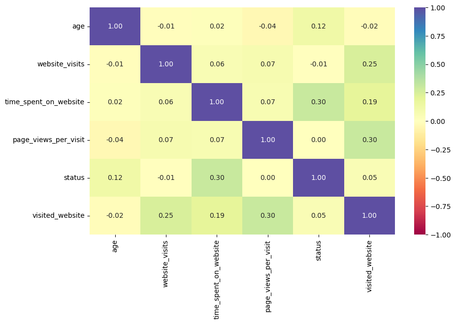

```python
# lets create a heatmap of the correlation matrix for the numeric columns in our leads_data dataset.

# Select numeric columns in the dataset
cols_list = leads_data.select_dtypes(include=np.number).columns.tolist()

# Set up the matplotlib figure
plt.figure(figsize=(10, 6))

# Create a heatmap using Seaborn
sns.heatmap(leads_data[cols_list].corr(), annot=True, vmin=-1, vmax=1, fmt=".2f", cmap="Spectral")

# Show the plot
plt.show()
```

```python
# creating a correlation matrix of the dataset
numeric_columns = leads_data.select_dtypes(include=np.number)

# Compute the correlation matrix
correlation_matrix = numeric_columns.corr()

# Display the correlation matrix
print(correlation_matrix)
```

```
                          age  website_visits  time_spent_on_website  \
age                    1.0000         -0.0120                 0.0189
website_visits        -0.0120          1.0000                 0.0623
time_spent_on_website  0.0189          0.0623                 1.0000
page_views_per_visit  -0.0407          0.0741                 0.0681
status                 0.1221         -0.0066                 0.3021
visited_website       -0.0195          0.2497                 0.1928

                       page_views_per_visit  status  visited_website
age                                 -0.0407  0.1221          -0.0195
website_visits                       0.0741 -0.0066           0.2497
time_spent_on_website                0.0681  0.3021           0.1928
page_views_per_visit                 1.0000  0.0003           0.3045
status                               0.0003  1.0000           0.0496
visited_website                      0.3045  0.0496           1.0000
```

### Observation:

Age and Website Visits: Weak negative correlation (-0.0120). Older leads tend to have slightly fewer website visits.

Website Visits and Time Spent on Website: Positive correlation (0.0623). Leads who visit the website more frequently tend to spend more time on it.

Time Spent on Website and Page Views Per Visit: Positive correlation (0.0681). Longer time spent on the website is associated with a higher average page views per visit.

Age and Page Views Per Visit: Weak negative correlation (-0.0407). Older leads tend to have slightly fewer page views per visit.

Age and Status (Conversion): Positive correlation (0.1221). Older leads are slightly more likely to convert to paid customers.

Website Visits and Visited Website: Positive correlation (0.2497). Leads who visit the website more frequently are more likely to have an overall interaction with the website.

Time Spent on Website and Status (Conversion): Moderate positive correlation (0.3021). Longer time spent on the website is associated with a higher likelihood of conversion.

Page Views Per Visit and Visited Website: Positive correlation (0.3045). Higher average page views per visit are associated with an overall interaction with the website.

Status (Conversion) and Visited Website: Positive correlation (0.0496). Leads who have an overall interaction with the website are slightly more likely to convert.

## Distribution Visualization of Predictor Variable with Respect to Target Variable

```python
## # Function to visualize the distribution of a predictor variable with respect to the target variable in leads_data of ExtraaLearn

def distribution_plot_wrt_target(leads_data, predictor, target):
    fig, axs = plt.subplots(2, 2, figsize=(12, 10))

    target_uniq = leads_data[target].unique()

    axs[0, 0].set_title("Distribution of " + predictor + " for " + target + "=" + str(target_uniq[0]))
    sns.histplot(
        data=leads_data[leads_data[target] == target_uniq[0]],
        x=predictor,
        kde=True,
        ax=axs[0, 0],
        color="teal",
        stat="density",
    )

    axs[0, 1].set_title("Distribution of " + predictor + " for " + target + "=" + str(target_uniq[1]))
    sns.histplot(
        data=leads_data[leads_data[target] == target_uniq[1]],
        x=predictor,
        kde=True,
        ax=axs[0, 1],
        color="orange",
        stat="density",
    )

    axs[1, 0].set_title("Boxplot w.r.t " + target)
    sns.boxplot(data=leads_data, x=target, y=predictor, ax=axs[1, 0], palette="gist_rainbow")

    axs[1, 1].set_title("Boxplot (without outliers) w.r.t " + target)
    sns.boxplot(
        data=leads_data,
        x=target,
        y=predictor,
        ax=axs[1, 1],
        showfliers=False,
        palette="gist_rainbow",
    )

    plt.tight_layout()
    plt.show()
```

## Stacked Barplot and Category Counts for Target vs. Predictor in leads_data

```python
# Function to plot a stacked bar chart and display category counts for target variable across different predictor categories in leads_data

def stacked_barplot_leads_data(leads_data, predictor, target):
    """
    Print the category counts and plot a stacked bar chart for the leads_data dataset

    leads_data: dataframe
    predictor: independent variable
    target: target variable
    """
    count = leads_data[predictor].nunique()
    sorter = leads_data[target].value_counts().index[-1]
    tab1 = pd.crosstab(leads_data[predictor], leads_data[target], margins=True).sort_values(
        by=sorter, ascending=False
    )
    print(tab1)
    print("-" * 120)
    tab = pd.crosstab(leads_data[predictor], leads_data[target], normalize="index").sort_values(
        by=sorter, ascending=False
    )
    tab.plot(kind="bar", stacked=True, figsize=(count + 5, 5))
    plt.legend(
        loc="lower left", frameon=False,
    )
    plt.legend(loc="upper left", bbox_to_anchor=(1, 1))
    plt.show()
```

## Analysis of Current Occupation against Status

```
status                 0     1   All
current_occupation
All                 3235  1377  4612
Professional        1687   929  2616
Unemployed          1058   383  1441
Student              490    65   555
------------------------------------------------------------------------------------------------------------------------
```

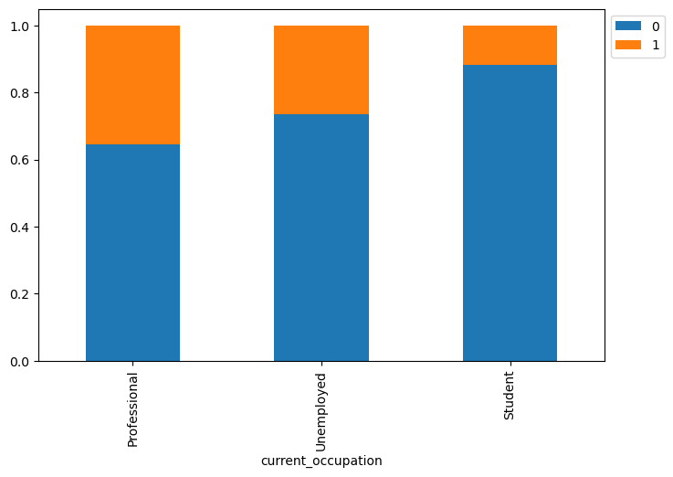

```python
stacked_barplot_leads_data(leads_data, "current_occupation", "status")
```

## Computing Further Plot Pairs for the Data Features

## First Interaction vs. Status

```
status                0     1   All
first_interaction
All                3235  1377  4612
Website            1383  1159  2542
Mobile App         1852   218  2070
------------------------------------------------------------------------------------------------------------------------
```

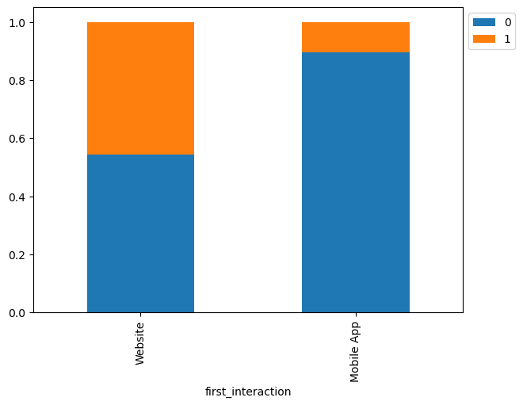

```python
# First Interaction vs. Status
count = leads_data["first_interaction"].nunique()
stacked_barplot_leads_data(leads_data, "first_interaction", "status");
```

## Profile Completed vs. Status

```
status                0     1   All
profile_completed
All                3235  1377  4612
High               1318   946  2264
Medium             1818   423  2241
Low                  99     8   107
------------------------------------------------------------------------------------------------------------------------
```

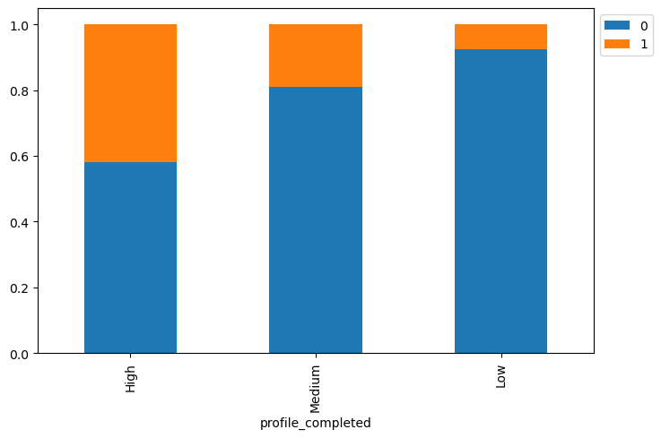

```python
#Profile Completed vs. Status
count = leads_data["profile_completed"].nunique()
stacked_barplot_leads_data(leads_data, "profile_completed", "status")
```

## Website Visits vs. Status

```
status             0     1   All
website_visits
All             3235  1377  4612
2                856   373  1229
1                520   235   755
3                421   220   641
4                361   133   494
5                300   122   422
6                190    92   282
7                172    60   232
8                105    46   151
0                142    32   174
9                 63    15    78
11                16    13    29
10                24    10    34
```

[output cut: 16 more lines]

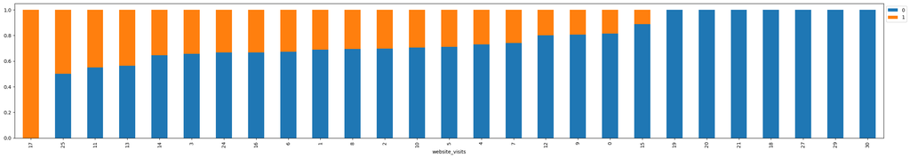

```python
# Website Visits vs. Status
stacked_barplot_leads_data(leads_data, "website_visits", "status")
```

## Last Activity vs. Status

```
status               0     1   All
last_activity
All               3235  1377  4612
Email Activity    1587   691  2278
Website Activity   677   423  1100
Phone Activity     971   263  1234
------------------------------------------------------------------------------------------------------------------------
```

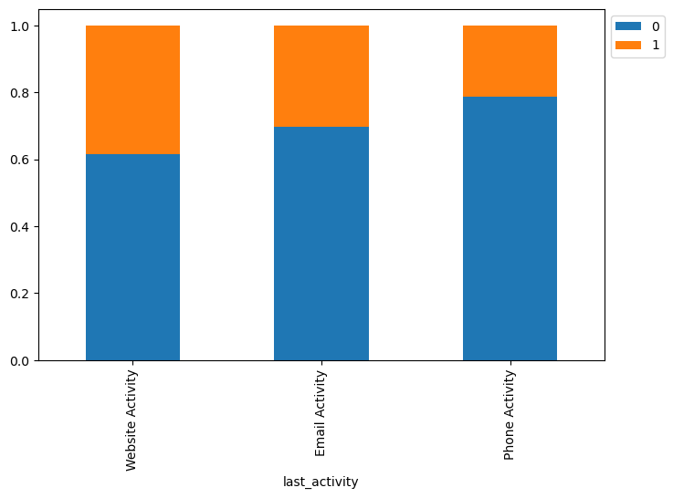

```python
# Last Activity vs. Status
count = leads_data["last_activity"].nunique()
stacked_barplot_leads_data(leads_data, "last_activity", "status")
```

## Print Media Type 1 vs. Status

```
status                0     1   All
print_media_type1
All                3235  1377  4612
No                 2897  1218  4115
Yes                 338   159   497
------------------------------------------------------------------------------------------------------------------------
```

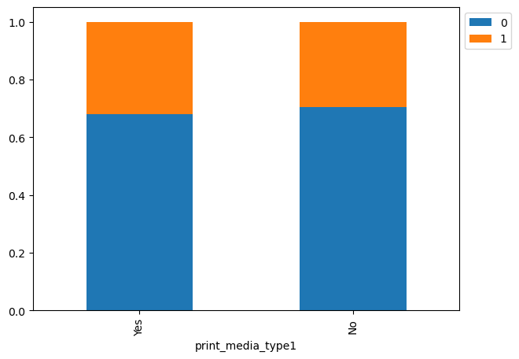

```python
# Print Media Type 1 vs. Status
count = leads_data["print_media_type1"].nunique()
stacked_barplot_leads_data(leads_data, "print_media_type1", "status")
```

## Print Media Type 2 vs. Status

```
status                0     1   All
print_media_type2
All                3235  1377  4612
No                 3077  1302  4379
Yes                 158    75   233
------------------------------------------------------------------------------------------------------------------------
```

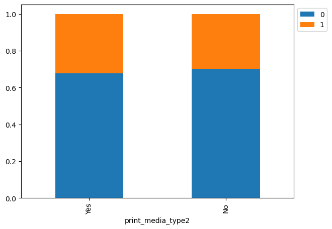

```python
# Print Media Type 2 vs. Status
count = leads_data["print_media_type2"].nunique()
stacked_barplot_leads_data(leads_data, "print_media_type2", "status")
```

## Digital Media vs. Status

```
status            0     1   All
digital_media
All            3235  1377  4612
No             2876  1209  4085
Yes             359   168   527
------------------------------------------------------------------------------------------------------------------------
```

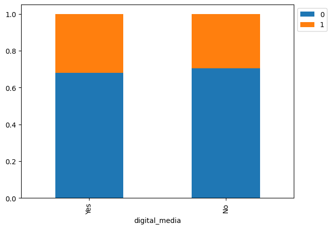

```python
# Digital Media vs. Status
count = leads_data["digital_media"].nunique()
stacked_barplot_leads_data(leads_data, "digital_media", "status")
```

## Educational Channels vs. Status

```
status                   0     1   All
educational_channels
All                   3235  1377  4612
No                    2727  1180  3907
Yes                    508   197   705
------------------------------------------------------------------------------------------------------------------------
```

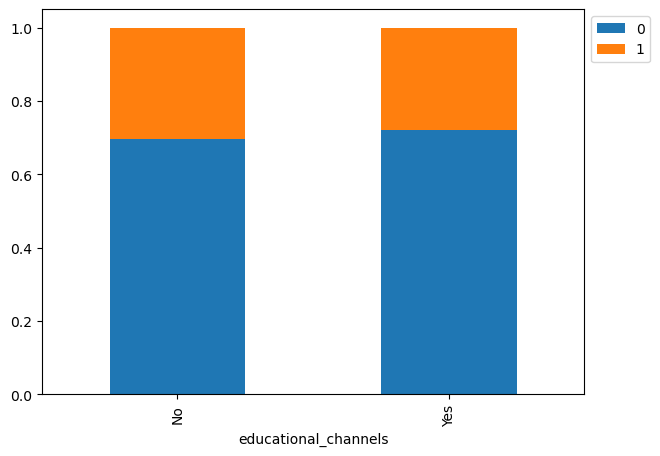

```python
# Educational Channels vs. Status
count = leads_data["educational_channels"].nunique()
stacked_barplot_leads_data(leads_data, "educational_channels", "status")
```

## Referral vs. Status

```
status       0     1   All
referral
All       3235  1377  4612
No        3205  1314  4519
Yes         30    63    93
------------------------------------------------------------------------------------------------------------------------
```

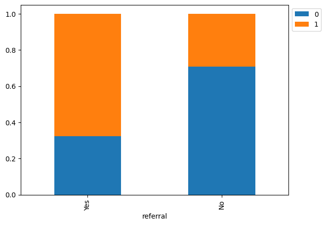

```python
# Referral vs. Status
count = leads_data["referral"].nunique()
stacked_barplot_leads_data(leads_data, "referral", "status")
```

## Data Preprocessing

- Missing value treatment (if needed)
- Feature engineering (if needed)
- Outlier detection and treatment (if needed)
- Preparing data for modeling
- Any other preprocessing steps (if needed)

## Check for Outliers in the Data

```python
# defining a function to detect outliers using the boxplot when returned
def detect_outliers(data, columns):
    """
    Detect outliers in the specified columns using boxplot.

    Parameters:
    - data: DataFrame
    - columns: List of columns to check for outliers

    Returns:
    - Dictionary containing column names and corresponding outlier indices
    """
    outliers_dict = {}

    plt.figure(figsize=(15, 8))

    for i, column in enumerate(columns):
        plt.subplot(2, 2, i + 1)

        # Creating a boxplot for the column
        sns.boxplot(x=data[column])
        plt.title(f'Boxplot for {column}')

        # Finding the indices of outliers using the boxplot
        Q1 = data[column].quantile(0.25)
        Q3 = data[column].quantile(0.75)
        IQR = Q3 - Q1
        lower_bound = Q1 - 1.5 * IQR
        upper_bound = Q3 + 1.5 * IQR

        outliers = data[(data[column] < lower_bound) | (data[column] > upper_bound)].index
        outliers_dict[column] = outliers

    plt.tight_layout()
    plt.show()

    return outliers_dict
```

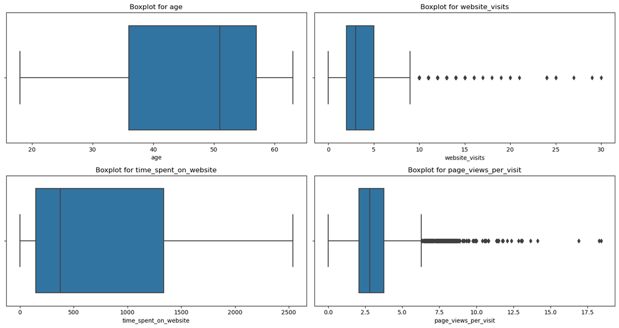

```
{'age': Int64Index([], dtype='int64'), 'website_visits': Int64Index([   6,   31,   32,   66,  201,  202,  212,  262,  266,  311,
            ...
            4465, 4468, 4510, 4536, 4539, 4566, 4571, 4583, 4589, 4607],
           dtype='int64', length=154), 'time_spent_on_website': Int64Index([], dtype='int64'), 'page_views_per_visit': Int64Index([   4,   32,   47,  110,  121,  125,  135,  141,  183,  196,
            ...
            4298, 4301, 4340, 4433, 4466, 4470, 4507, 4514, 4572, 4597],
           dtype='int64', length=257)}
```

```python
outliers = detect_outliers(leads_data, ["age", "website_visits", "time_spent_on_website", "page_views_per_visit"])
print(outliers)
```

### Observations

Age: No outliers detected in the 'age' feature.

Website Visits: There are 154 outliers in the 'website_visits' feature. Outliers could indicate leads that have an unusually high number of website visits.

Time Spent on Website: No outliers detected in the 'time_spent_on_website' feature.

Page Views Per Visit: There are 257 outliers in the 'page_views_per_visit' feature. Outliers could indicate leads with an unusually high average number of pages viewed per visit.

## Missing Value Treatment

```python
# Lets check for missing values from our dataset leads_data
leads_data.isnull().sum()
```

```
ID                       0
age                      0
current_occupation       0
first_interaction        0
profile_completed        0
website_visits           0
time_spent_on_website    0
page_views_per_visit     0
last_activity            0
print_media_type1        0
print_media_type2        0
digital_media            0
educational_channels     0
referral                 0
status                   0
visited_website          0
dtype: int64
```

### Checks show there are no missing values in our dataset

## Preparing The Data for Modeling

```python
## Creating feature matrix (X) and target variable (Y), one-hot encoding, and splitting the data

X = leads_data.drop(["status"], axis=1)
Y = leads_data["status"]

X = pd.get_dummies(X, drop_first=True)  # One-hot encode categorical variables in X

# Splitting the data in a 70:30 ratio for train to test data
X_train, X_test, y_train, y_test = train_test_split(X, Y, test_size=0.30, random_state=1)
```

```python
# Displaying shapes and class distribution in the training and test sets
print("Shape of Training set : ", X_train.shape)
print("Shape of Test set : ", X_test.shape)
print("Percentage of classes in Training set:")
print(y_train.value_counts(normalize=True))
print("Percentage of classes in Test set:")
print(y_test.value_counts(normalize=True))
```

```
Shape of Training set :  (3228, 4628)
Shape of Test set :  (1384, 4628)
Percentage of classes in Training set:
0   0.7042
1   0.2958
Name: status, dtype: float64
Percentage of classes in Test set:
0   0.6951
1   0.3049
Name: status, dtype: float64
```

## EDA

- It is a good idea to explore the data once again after manipulating it.

### Observation

Percentage of classes in Training set: Class 0 (Not converted): 70.42% Class 1 (Converted): 29.58%

Percentage of classes in Test set: Class 0 (Not converted): 69.51% Class 1 (Converted): 30.49%

## Model Evaluation Metrics and Confusion Matrix Display Function

```python
# Function to display classification metrics and confusion matrix for model evaluation
def metrics_score(actual, predicted):
    print(classification_report(actual, predicted))

    cm = confusion_matrix(actual, predicted)

    plt.figure(figsize=(8, 5))

    sns.heatmap(cm, annot=True, fmt='.2f', xticklabels=['Not Converted', 'Converted'], yticklabels=['Not Converted', 'Converted'])

    plt.ylabel('Actual')

    plt.xlabel('Predicted')

    plt.title('Confusion Matrix')

    plt.show()
```

## Building a Decision Tree model

```python
# Creating a Decision Tree Classifier instance
decision_tree_model = DecisionTreeClassifier(random_state=1)

# Training the decision tree model using the training data
decision_tree_model.fit(X_train, y_train)
```

```
DecisionTreeClassifier(random_state=1)
```

```
              precision    recall  f1-score   support

           0       1.00      1.00      1.00      2273
           1       1.00      1.00      1.00       955

    accuracy                           1.00      3228
   macro avg       1.00      1.00      1.00      3228
weighted avg       1.00      1.00      1.00      3228
```

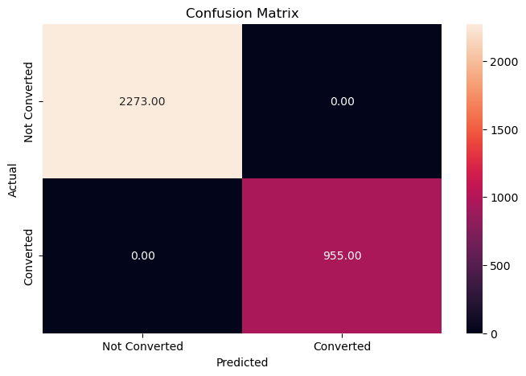

```python
# Making predictions on the training data using the trained decision tree model
y_pred_train = decision_tree_model.predict(X_train)

# Evaluating the model performance on the training data
metrics_score(y_train, y_pred_train)
```

### Observation

Precision, Recall, and F1-Score for Class 0 and Class 1: Precision, Recall, and F1-Score are all 1.00 for both classes (0 and 1). This indicates that the model's predictions for both classes are perfect, with no False Positives or False Negatives.

Accuracy: The overall accuracy of the model on the training data is 1.00 (100%), indicating that all predictions (both positive and negative) are correct.

Macro Average and Weighted Average: Macro Average and Weighted Average for precision, recall, and F1-score are all 1.00. These metrics consider the average performance across classes, and in this case, they show that the model performs perfectly on average.

## Do we need to prune the tree?

### I prefer to perform hyperparameter tuning for the decision tree instead of pruning.

Reasons: Given the observations of perfect precision, recall, and F1-Score for both classes (0 and 1), as well as an overall accuracy of 1.00 (100%), it suggests that the model may be overfitting the training data. Overfitting occurs when a model learns the training data too well, including noise and outliers, and may not generalize well to new, unseen data.

```python
from sklearn.metrics import recall_score

# Choose the type of classifier
tuned_decision_tree_model = DecisionTreeClassifier(random_state=7, class_weight={0: 0.3, 1: 0.7})

# Grid of parameters to choose from
tuning_parameters = {
    'max_depth': np.arange(2, 10),
    'criterion': ['gini', 'entropy'],
    'min_samples_leaf': [5, 10, 20, 25]
}

# Type of scoring used to compare parameter combinations - recall score for class 1
scorer = metrics.make_scorer(recall_score, pos_label=1)

# Run the grid search
grid_search = GridSearchCV(tuned_decision_tree_model, tuning_parameters, scoring=scorer, cv=5)

grid_search = grid_search.fit(X_train, y_train)

# Set the classifier to the best combination of parameters
tuned_decision_tree_model = grid_search.best_estimator_

# Fit the best algorithm to the data
tuned_decision_tree_model.fit(X_train, y_train)
```

```
DecisionTreeClassifier(class_weight={0: 0.3, 1: 0.7}, criterion='entropy',
                       max_depth=3, min_samples_leaf=5, random_state=7)
```

```
              precision    recall  f1-score   support

           0       0.94      0.77      0.85      2273
           1       0.62      0.88      0.73       955

    accuracy                           0.80      3228
   macro avg       0.78      0.83      0.79      3228
weighted avg       0.84      0.80      0.81      3228
```

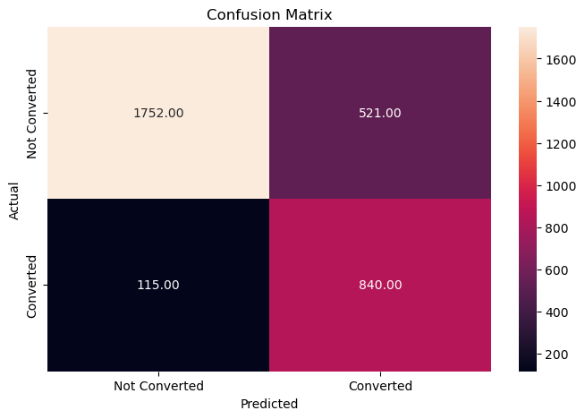

```python
# Checking performance on the training data
# Checking performance on the training data
y_pred_train2 = tuned_decision_tree_model.predict(X_train)

# Printing the metrics scores
metrics_score(y_train, y_pred_train2)
```

### Observations on training data performance:

The model shows a decent performance, with good precision (especially for Class 0) but lower precision for Class 1. Recall for Class 1 is relatively high, indicating that the model is effective in identifying converted leads. The overall accuracy is 80%, suggesting that the model is reasonably accurate in predicting lead conversion. The macro and weighted averages provide a summary across both classes, showing a balanced evaluation. These metrics indicate that the tuned decision tree model performs reasonably well except for class 1.

```
              precision    recall  f1-score   support

           0       0.93      0.77      0.84       962
           1       0.62      0.86      0.72       422

    accuracy                           0.80      1384
   macro avg       0.77      0.82      0.78      1384
weighted avg       0.83      0.80      0.80      1384
```

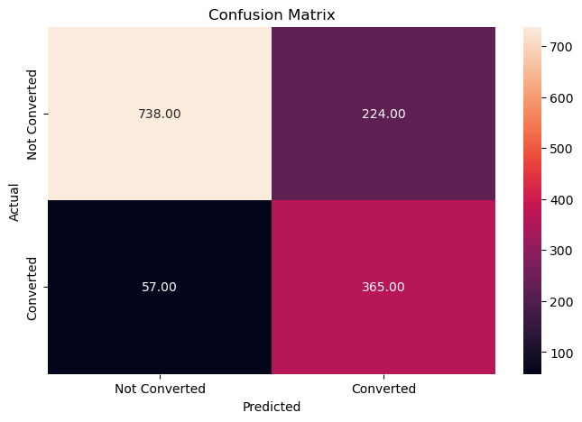

```python
# Checking performance on the testing data
y_pred_test2 = tuned_decision_tree_model.predict(X_test)

# Printing the metrics scores
metrics_score(y_test, y_pred_test2)
```

### Observations on test data performance:

The test performance metrics indicate how well the tuned decision tree model generalizes to new, unseen data. Here's an interpretation of the metrics:

Precision (0): 93% - This indicates that, among the instances predicted as "Not Converted" (class 0), 93% were actually "Not Converted."

Recall (0): 77% - This shows that out of all the actual "Not Converted" instances, the model correctly identified 77% of them.

F1-score (0): 84% - The F1-score is the harmonic mean of precision and recall. It provides a balance between precision and recall.

Precision (1): 62% - This indicates that, among the instances predicted as "Converted" (class 1), 62% were actually "Converted."

Recall (1): 86% - This shows that out of all the actual "Converted" instances, the model correctly identified 86% of them.

F1-score (1): 72% - The F1-score for class 1 is the harmonic mean of precision and recall for that class.

Accuracy: 80% - Overall accuracy of the model on the test set, indicating the proportion of correctly predicted instances.

Macro Avg: 78% - The macro average of precision, recall, and F1-score, considering both classes equally.

Weighted Avg: 80% - The weighted average of precision, recall, and F1-score, considering the imbalance in class distribution.

## Visualizing the Decision Tree

```
              precision    recall  f1-score   support

           0       0.93      0.77      0.84       962
           1       0.62      0.86      0.72       422

    accuracy                           0.80      1384
   macro avg       0.77      0.82      0.78      1384
weighted avg       0.83      0.80      0.80      1384
```

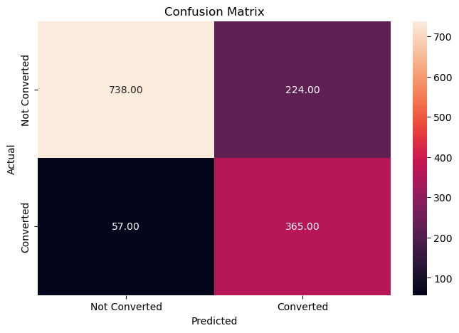

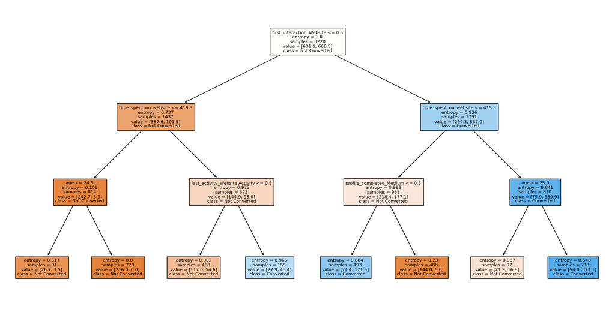

```python
from sklearn.tree import plot_tree

# Checking performance on the testing data
y_pred_test2 = tuned_decision_tree_model.predict(X_test)

# Printing the metrics scores
metrics_score(y_test, y_pred_test2)

# Plotting the decision tree
plt.figure(figsize=(20, 10))
plot_tree(tuned_decision_tree_model, feature_names=X.columns, class_names=['Not Converted', 'Converted'], filled=True, fontsize=8)
plt.show()
```

## Building a Random Forest model

```python
from sklearn.ensemble import RandomForestClassifier

# Creating a Random Forest Classifier instance
randomf_estimator = RandomForestClassifier(random_state=1, class_weight={0: 0.3, 1: 0.7})

# Fitting the Random Forest Classifier on the training data
randomf_estimator.fit(X_train, y_train)
```

```
RandomForestClassifier(class_weight={0: 0.3, 1: 0.7}, random_state=1)
```

```
              precision    recall  f1-score   support

           0       1.00      1.00      1.00      2273
           1       1.00      1.00      1.00       955

    accuracy                           1.00      3228
   macro avg       1.00      1.00      1.00      3228
weighted avg       1.00      1.00      1.00      3228
```

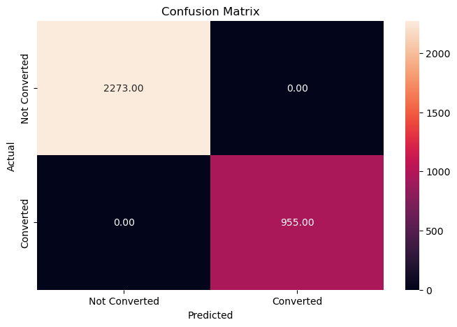

```python
# Checking performance on the training data
y_pred_train3 = randomf_estimator.predict(X_train)

# Printing the metrics scores
metrics_score(y_train, y_pred_train3)
```

### Observation of the Random Forest Model on the traing data:

The observation from the metrics scores is that the RandomForestClassifier has achieved perfect accuracy, precision, recall, and F1-score for both classes (0 and 1) on the training data. This indicates that the model's predictions are flawless, with no False Positives or False Negatives. The macro and weighted averages are also 1.00, showing that the model performs perfectly on average across classes. Furher performance assessment on test data will tell if there's overfitting.

```
              precision    recall  f1-score   support

           0       0.86      0.94      0.90       962
           1       0.84      0.64      0.72       422

    accuracy                           0.85      1384
   macro avg       0.85      0.79      0.81      1384
weighted avg       0.85      0.85      0.85      1384
```

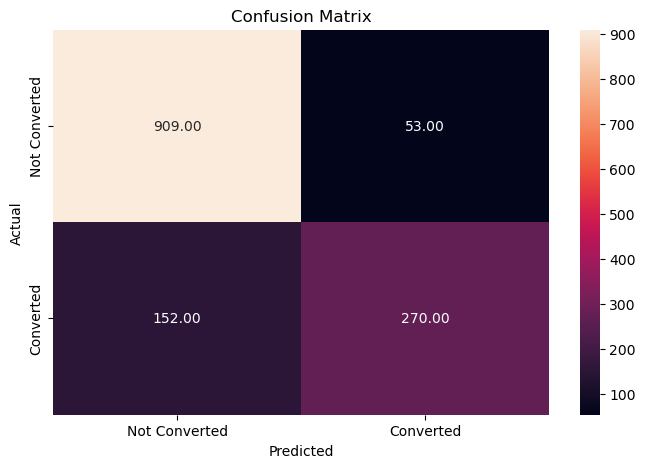

```python
# Checking performance on the testing data
y_pred_test3 = randomf_estimator.predict(X_test)

# Printing the metrics scores
metrics_score(y_test, y_pred_test3)
```

### Observation on test data:

Accuracy: The overall accuracy of the model on the test data is 0.85 (85%), which is a good performance. It suggests that the model is making correct predictions for the majority of instances.

## Do we need to prune the tree?

### I will opt for 'Hyperparameter Tuning' instead

```python
# Define the Random Forest Classifier with tuned hyperparameters
random_forest_tuned = RandomForestClassifier(criterion="entropy", random_state=7)

# Specify hyperparameter grid for tuning
hyperparameters = {
    "n_estimators": [110, 120],
    "max_depth": [6, 7],
    "min_samples_leaf": [20, 25],
    "max_features": [0.8, 0.9],
    "max_samples": [0.9, 1],
    "class_weight": ["balanced", {0: 0.3, 1: 0.7}]
}

# Choose the scoring metric for parameter optimization - recall score for class 1
scorer = metrics.make_scorer(recall_score, pos_label=1)

# Perform grid search on the training data using scorer and 5-fold cross-validation
grid_search = GridSearchCV(random_forest_tuned, hyperparameters, scoring=scorer, cv=5)
grid_search = grid_search.fit(X_train, y_train)

# Save the best estimator to the variable random_forest_tuned
random_forest_tuned = grid_search.best_estimator_
```

```python
# Fit the best Random Forest model to the training data
random_forest_tuned.fit(X_train, y_train)
```

```python
# Checking performance on the training data using the tuned Random Forest model
y_pred_train_rf_tuned = random_forest_tuned.predict(X_train)

# Displaying the metrics scores for the training data
metrics_score(y_train, y_pred_train_rf_tuned)
```

[output not shown]

## Actionable Insights and Recommendations

Summary of Actionable Insights for ExtraaLearn's Leads Data:

Highly Effective Models:

Allocate resources to engage leads with prolonged website activity and enhance email communication strategies. Continuous Monitoring and Adaptation:

Regularly update models with fresh data and adapt marketing strategies based on evolving trends and customer behaviors. Exploration and Testing:

Explore additional lead generation channels and conduct A/B testing for marketing approaches to optimize conversion. Customer Segmentation:

Implement segmentation based on demographics and behavior for more targeted marketing campaigns. Feedback Loop:

Establish a feedback loop with the sales team to refine models based on successful conversion insights. Conclusion:

By implementing these insights, ExtraaLearn can maximize lead conversion rates, optimize resource allocation, and stay adaptable in a dynamic market